# Extra Credit - learning curves

Joshua Welch

April 18, 2018

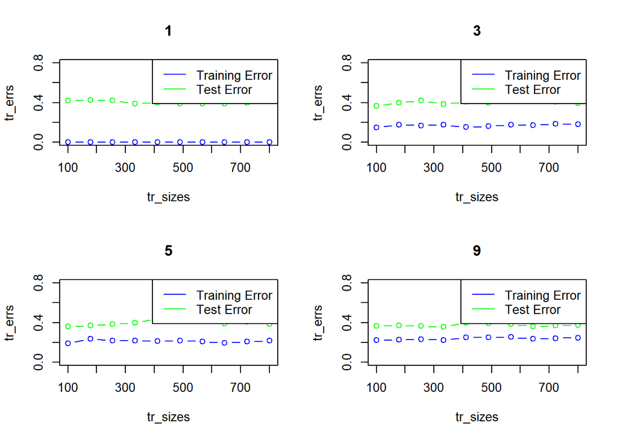

```r
# see how knn classifier works as training size changes


ks = c(1, 3, 5, 9)
par(mfrow=c(2,2))

for(k in ks){

te_errs = c()

tr_errs = c()

te_actual = te_dat$bad.loan

tr_sizes = seq(100, nrow(tr_dat), length.out=10)



for (tr_size in tr_sizes) {

  tr_dat1 = tr_dat[1:tr_size,]

  tr_actual = tr_dat1$bad.loan

  fit = knn3(bad.loan ~ duration.in.months + amount, data=tr_dat1, k=k)


  # error on training set

  tr_predicted = predict(fit, tr_dat1, type="class")

  err = mean(tr_actual != tr_predicted)

  tr_errs = c(tr_errs, err)



  # error on test set

  te_predicted = predict(fit, te_dat, type="class")

  err = mean(te_actual != te_predicted)

  te_errs = c(te_errs, err)

}


#




# Plot learning curve here

plot(tr_sizes, tr_errs,  col="blue", main=k, type="b", ylim=c(0,.8))
lines(tr_sizes,te_errs, col="green", type="b")
legend("topright", c("Training Error","Test Error"), col= c("blue","green"), lty=1)
#

}
```

## Explain the curves you get. For example, what’s with the low training error when k = 1?

The low training error when k=1 is a result of overfitting that allows for the model to fit perfectly to the data leaving no error. As k increases we see our training error increase, while the same time our test error is decreasing. From this plot a larger number like 9 would be the best k to choose to have a better model with lower test error.

## What do the learning curves tell you? Write some sentences to explain what the learning curves tell you about bias and variance.

When we start off with using k=1 are model is too simple and flexes to our data yeilding in high variance and a low bias. As k increases our variance starts to go down as our model becomes less flexible. At the same time our bias is increasing as k increases.

## Model 2

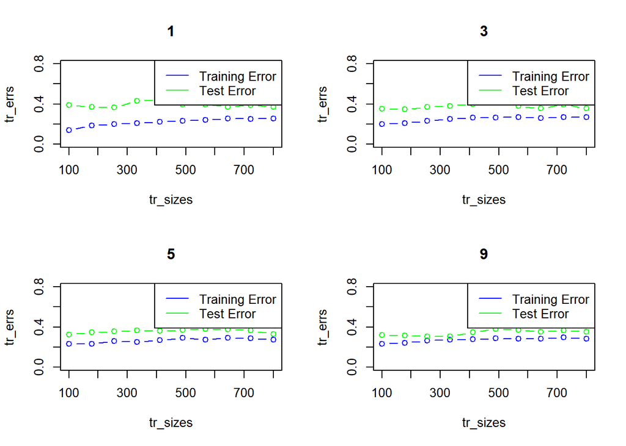

```r
par(mfrow=c(2,2))

for(k in ks){

te_errs = c()

tr_errs = c()

te_actual = te_dat$bad.loan

tr_sizes = seq(100, nrow(tr_dat), length.out=10)



for (tr_size in tr_sizes) {

  tr_dat1 = tr_dat[1:tr_size,]

  tr_actual = tr_dat1$bad.loan

  fit = knn3(bad.loan ~ percentage.of.disposable.income + age.in.years, data=tr_dat1, k=k)


  # error on training set

  tr_predicted = predict(fit, tr_dat1, type="class")

  err = mean(tr_actual != tr_predicted)

  tr_errs = c(tr_errs, err)



  # error on test set

  te_predicted = predict(fit, te_dat, type="class")

  err = mean(te_actual != te_predicted)

  te_errs = c(te_errs, err)

}


#




# Plot learning curve here

plot(tr_sizes, tr_errs,  col="blue", main=k, type="b", ylim=c(0,.8))
lines(tr_sizes,te_errs, col="green", type="b")
legend("topright", c("Training Error","Test Error"), col= c("blue","green"), lty=1)
#

}
```

## Model 3

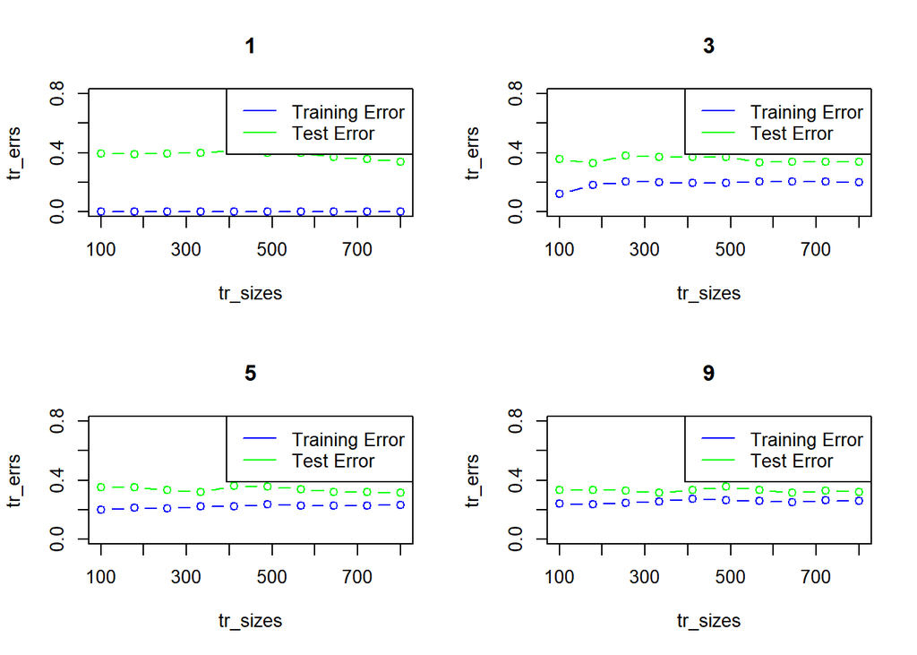

```r
par(mfrow=c(2,2))

for(k in ks){

te_errs = c()

tr_errs = c()

te_actual = te_dat$bad.loan

tr_sizes = seq(100, nrow(tr_dat), length.out=10)



for (tr_size in tr_sizes) {

  tr_dat1 = tr_dat[1:tr_size,]

  tr_actual = tr_dat1$bad.loan

  fit = knn3(bad.loan ~ percentage.of.disposable.income + age.in.years + duration.in.months + amount, data=tr_dat1, k=k)


  # error on training set

  tr_predicted = predict(fit, tr_dat1, type="class")

  err = mean(tr_actual != tr_predicted)

  tr_errs = c(tr_errs, err)



  # error on test set

  te_predicted = predict(fit, te_dat, type="class")

  err = mean(te_actual != te_predicted)

  te_errs = c(te_errs, err)

}


#




# Plot learning curve here

plot(tr_sizes, tr_errs,  col="blue", main=k, type="b", ylim=c(0,.8))
lines(tr_sizes,te_errs, col="green", type="b")
legend("topright", c("Training Error","Test Error"), col= c("blue","green"), lty=1)
#

}
```

This 3rd model I decided to combine the first and second models by looking at all 4 columns. This model does perform the best of the 3 having the lowest test error rate, but the improvement isn’t huge and for a larger data set the first model might be prefered.